# Visualizing the Beautiful Game

Will Cramer and Noah Gabriel

11/7/2019

Some call it “The Beautiful Game.” Others fondly refer to it as, “America’s Favorite Pastime.” Yet to the communities who play, it’s simply called Magic: the Gathering. Magic is a wonderfully complex game and has evolved greatly since its initial release in 1993. A few core elements, however, have stayed the same. First, the premise of the game has not changed — it is still to defeat your opposing wizard in battle by summoning creatures, attacking them until their “life total” drops from 20 to 0. Second, the “mana system,” or method by which one plays cards, is the same. Mana is magical energy which has five colors: white, blue, black, red, and green, arranged in a pentagram (e.g., black’s “allies” are blue and red).  
Each color possesses a distinct philosophy which is reflected in the design of the game. White is the color of justice, order, and the law. Blue is the color of knowledge, curiosity, and learning. Black loves power; its greed lets it cheat death. Red is impulsive and aggressive and draws on the element of fire. Green is the color of slow, overpowering growth. Gameplay reflects each of these themes; for example, green’s power of growth allows it to summon massive creatures.  
As the game has evolved, creatures have steadily grown in power because a design catch-22 called “power creep.” In order to keep new cards relevant, the designers have slowly made creatures stronger. A “Wurm” in 2019 will probably exceed its (admittedly vast) 1993 counterpart. This phenomenon may challenge the traditional roles of certain creatures or colors, yet it also showcases the fluid, dynamic, creative landscape of Magic: The Gathering. Below, we will take you on a tour of the Multiverse, using a wonderful dataset that contained every card printed, ever.

note: while we wanted to include an image, we were unable to do so. For an example of a typical card, see: [Enormous Baloth](https://img.scryfall.com/cards/large/front/5/4/54069e65-eef4-4fb8-bb0d-932a4c9889b3.jpg?1561980315)

From top to bottom, you can see the name, image, type and subtype (creature — Beast), flavor text (read it!), and in the bottom right, the power and toughness.

The Magic: the Gathering universe is filled with mythical creatures of all types, from diminutive goblins to prodigious Beasts, which embody the five colors of mana. Naturally, they differ in size. A Beast may crush a human underhoof, but stands but little chance before the rapacious maw of a Worldspine Wurm. Below the average size of some different creatures can be seen.

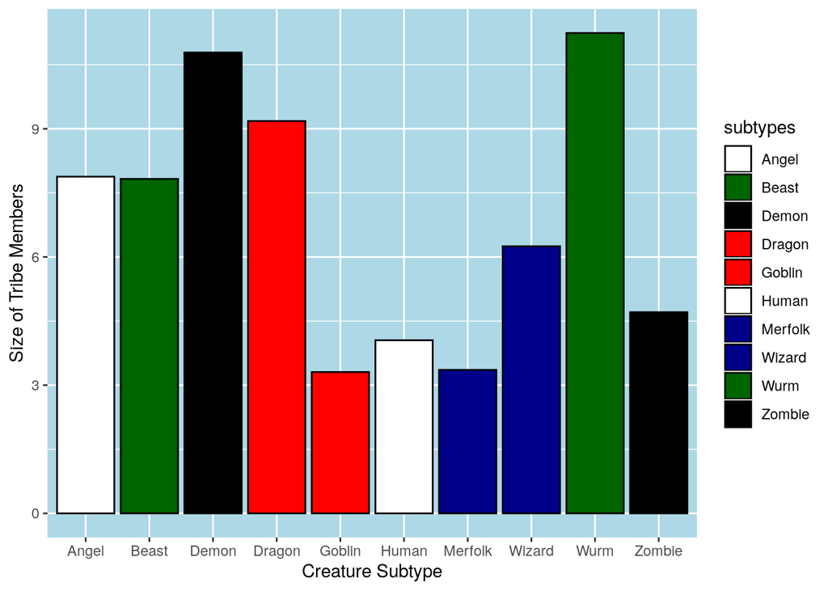

Making up this size, every creature is assigned a “power” and “toughness,” represented by the first and second digits in the bottom right corner of their cards, respectively. Overall, power and toughness tend to be fairly balanced all time. This becomes clear when looking at the card pool of all creatures ever printed.

[output not shown]

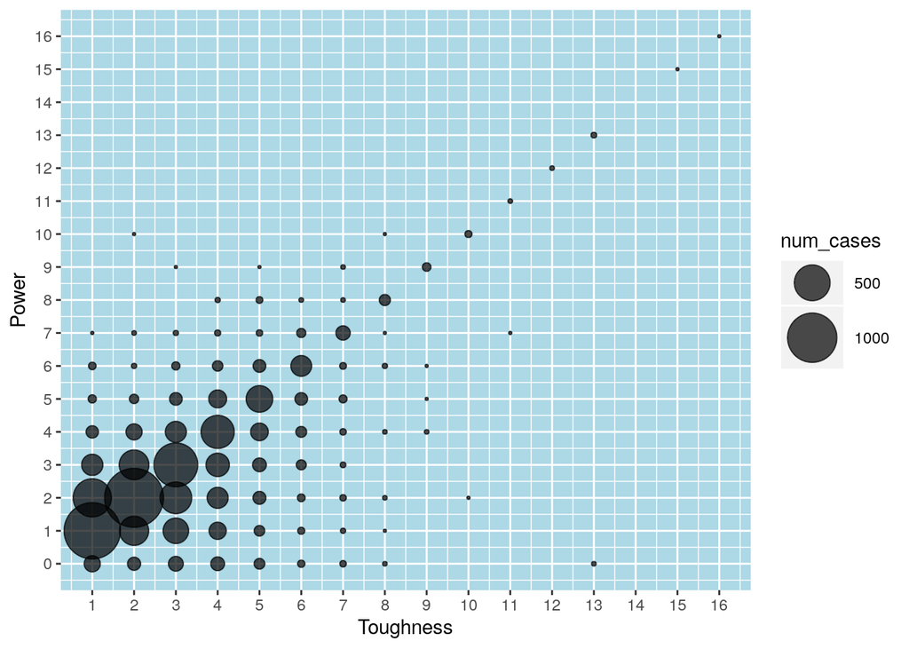

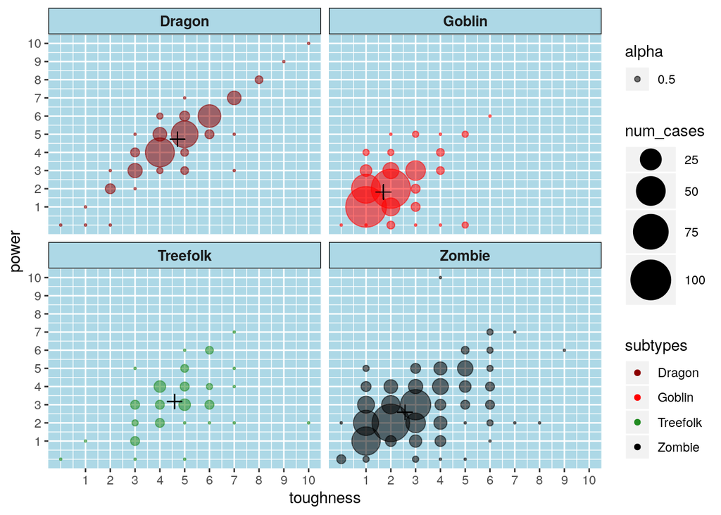

While many creatures fall into specific tribes that commonly occur throughout the MTG multiverse, nearly as many do not. As a result, we must also look beyond tribe and at what is perhaps Magic’s hallmark category breakdown: color. As mentioned above, colors have different assocations and their creatures help embody that notion. While green, the color of primieval beasts and monstrosities, has nearly always boasted more powerful creatures than any of its fellows and thus retained a dominant position, the hierarchy between the other four colors is less clear. What is obvious, however, is the data-backed notion of “power-creep,” or the steady ascent of power levels over time. This can be seen clearly in the graphic across all colors, especially in the last decade.

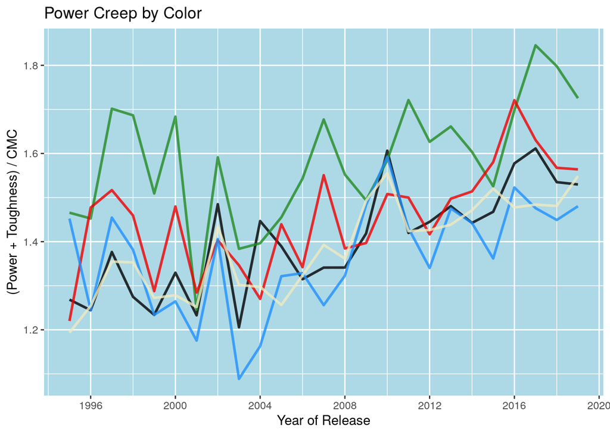

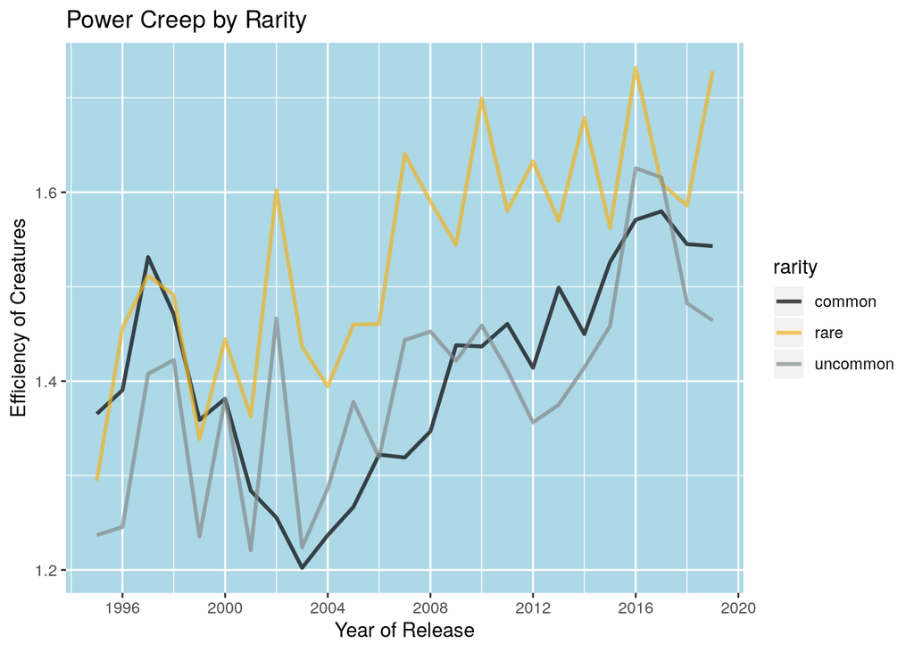

Thus, the MtG Multiverse is a many-layered, complex ecosystem. Like all ecosystems, it exists in a state of dynamic equalibrium. Both designers and players help maintain this balance; design tries to balance power levels, while players adjust to popular strategies to keep them in check. A Wurm may crush a Beast or a Human, but has a much harder time protecting its caster against a swarm of tiny Goblins. Like all ecosystems, the Multiverse evolves and grows. Creatures lose their comparative advantages and go “extinct,” and new ones take their place. This is all natural and good… yet it’s impossible not to feel some nostalga for the past, when a 7/7 Beast with no abilities dominated the battlefield and caused your opposing wizard to cower in fear.

## Methodology:

This dataset was huge and required a lot of wrangling. We made many graphs that didn’t even make it into the final presentation, just because we were curious about trends in the game.

In the beginning, we decided (1) we wanted to look at the evolution of the game, so we needed to find a way to join time to our dataset, and (2) we just wanted to look at creatures, as they’re the simplest to explain. For the first goal, we used the setcode marker in each card to join the sets dataset, which contained year of release. Then we converted the dates to year, arranged by (name, year), and used the distinct() function so that we could eliminate reprinted/rereleased cards (of which there are many). After this, we used the grepl function to filter down to only creatures, and used some str functions to modify subtypes so they would be easier to visualize. This was all the initial wrangling we needed to do. From this point on, making the graphs was fairly simple.

First graph: we chose bars, since x is categorical and bars are quite easy to grasp. We didn’t want to make anything too complex at the start. We mapped colors onto the creature types that fit them to illustrate what we were saying above.  
Second graph: We chose point with a low alpha to show how most creatures were concentrated around 2/2, and to show the symmetrical nature of design. This, we though, would tie into our next graph nicely. Third graph: This one took a ton of work but was really fun to make. The core problem is that creatures sometimes have many subtypes, and each was showing up as a distinct row— e.g., there may have been 70 2/2 Zombies, but another 10 2/2 Zombie Clerics, which were showing up seperately on the graph. To get around this, we pulled out 4 seperate datasets for each type, mutated the creature types so they were simply “Zombie” etc., converted to a dataframe so we could lapply() and merge together the like rows (70 2/2 Zombies + 10 2/2 Zombies), then converted back to dataframes and used bindrows() to mush it all back together. We also decided to add a mean power/toughness point to help with interpretation. Like mentioned before, we used a similar geom now that the reader was already familiar with it. Unfortunately, we weren’t able to rework the legend… it was much more complex because so many variables were involved.  
Fourth Graph: Moving into the line graphs (showing evolution over time), these were both quite simple. Just a few group_by() and summarize() functions. The colors were intuitive too. Fifth Graph: Same as fourth, honestly.